# Project Final Submission Template

### Step 1a: Planning

#### Identify the information in the file your program will read

When I open gender_inequality.csv, I see that it contains many columns of information for each country and their ranking on the GII. Each column contains

- the country
- the continent
- the subregion
- the gender inequality index
- the maternal mortality ratio
- the adolescent birth rate
- the percent representation in parliament
- the population with secondary education (female)
- the population with secondary education (male)
- the labour force participation rate (female)
- the labour force participation rate (male)

some information in the columns are missing for certain countries and is replaced by .. on the table of data.

### Step 1b: Planning

#### Brainstorm ideas for what your program will produce

#### Select the idea you will build on for subsequent steps

I can output each country on a scatterplot graph with their GII ranking and the average of labour force participation rate in both men and women as the y and x axis. I can output each country onto a scatterplot graph with their GII ranking and their average population with secondary education (both men and women) as the y and x axis I can output each country onto a scatterplot graph with their GII ranking and the difference of population with secondary education between men and women as the y and x axis.

CHOSEN: I would like to work on producing each country onto a scatterplot graph with their GII ranking and their average population with secondary education (both men and women) as the y and x axis

You must brainstorm at least three ideas for graphs or charts that your program could produce and choose the one that you'd like to work on. You can choose between a line chart, histogram, bar chart, scatterplot, or pie chart.

### Step 1c: Planning

#### Write or draw examples of what your program will produce

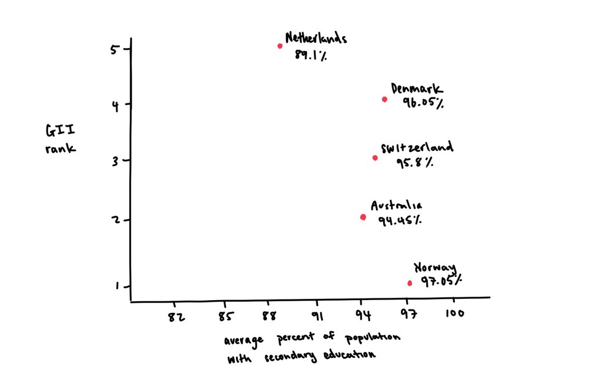

### Step 2a: Building

#### Document which information you will represent in your data definitions

#### Design data definitions

Before you design data definitions in the code cell below, you must explicitly document here which information in the file you chose to represent and why that information is crucial to the chart or graph that you'll produce when you complete step 2c.

```python
from cs103 import *
from typing import NamedTuple, List
import csv

##################
# Data Definitions

Country = NamedTuple('Country', [('name', str),
                                 ('gii_rank', int),
                                 ('pop_w_edu_f', float),
                                 ('pop_w_edu_m', float)])

# interp. a country with it's name, GII ranking, female population with secondary education (in percentage)
# and male popoulation with secondary education (in percentage)
C1 = Country('Norway', 1, 97.4, 96.7)
C2 = Country('Australia', 2, 94.3, 94.6)
C3 = Country('Switzerland', 3, 95, 96.6)
C4 = Country('Denmark', 4, 95.5, 96.6)
C5 = Country('Netherlands', 5, 87.7, 90.5)

#template based on compound
@typecheck
def fn_for_country(c: Country) -> ...:
    return ... (c.name,
                c.gii_rank,
                c.pop_w_edu_f,
                c.pop_w_edu_m)


# List[Country]
# interp. a list of countries

LOC0 = []
LOC1 = [C1, C2]
LOC2 = [C1, C2, C3, C4, C5]

#template based on arbitrary-sized and the reference rule
@typecheck
def fn_for_loc(loc: List[Country]) -> ...:
    #description of the acc
    acc = ... #typr: ...
    for c in loc:
        acc = ... (acc, fn_for_country(c))
    return ...(acc)
```

### Step 2b and 2c: Building

#### Design a function to read the information and store it as data in your program

#### Design functions to analyze the data

Complete these steps in the code cell below. You will likely want to rename the analyze function so that the function name describes what your analysis function does.

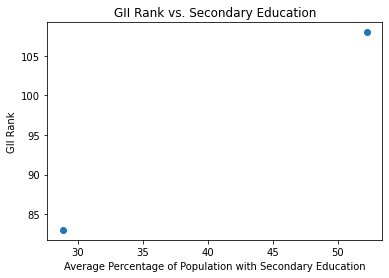

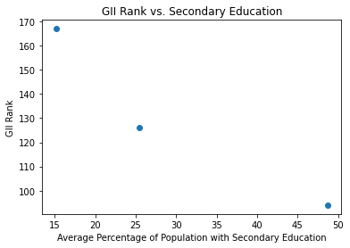

```
2 of 2 tests passed
5 of 5 tests passed
```

[figure not shown]

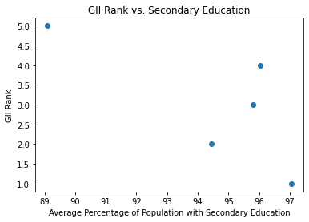

```
8 of 8 tests passed
```

```python
import matplotlib.pyplot as pyplot

###########
# Functions

@typecheck
def main(filename: str) -> None:
    """
    Reads the file from given filename, analyzes the data, returns the scatterplot graph
    """
    # Template from HtDAP, based on function composition
    return analyze(read(filename))


@typecheck
def read(filename: str) -> List[Country]:
    """
    reads information from the specified file and returns a list of countries
    """
    #return []  #stub
    # Template from HtDAP
    # loc contains the result so far
    loc = [] # type: List[Country]

    with open(filename) as csvfile:

        reader = csv.reader(csvfile)
        next(reader) # skip header line

        for row in reader:
            # you may not need to store all the rows, and you may need
            # to convert some of the strings to other types
            if is_reliable(row):
                c = Country(row[1], parse_int(row[0]), parse_float(row[8]), parse_float(row[9]))
                loc.append(c)

    return loc

@typecheck
def is_reliable(row: List[str]) -> bool:
    """
    Return True if the GII rank (row[0]), female population with secondary education (row[8])
    and male popoulation with secondary education (row[9]) is not empty.

    Assumes row is a full list of values from data dataset.
    Specifically, row[0], row[8] and row[9] must exist.

    blank data cells are not reliable since they indicate missing data.
    """

    #return True #stub

    # template

    return row[0] != "" and row[8] != ".." and row[9] != ".."


@typecheck
def analyze(country_data: List[Country]) -> None:
    """
    display a scatterplot of countries based on the following info: GII rank vs. average
    percentage of population with secondary education(both men and women)
    """
    #return None  #stub
    # Template from visualization

    pyplot.title('GII Rank vs. Secondary Education')
    pyplot.ylabel('GII Rank')
    pyplot.xlabel('Average Percentage of Population with Secondary Education')
    pyplot.scatter(get_edu_list(country_data), get_ranking_list(country_data))
    pyplot.show()

    return None

@typecheck
def get_ranking_list(loc: List[Country]) -> List[int]:
    '''
    returns the GII ranking of each country in the list of countries
    '''
    #return []  #stub
    #template from List[Country]

    # rank is a list of the rankings seen so far
    rank = []   # type: List[int]
    for c in loc:
        rank.append(c.gii_rank)

    return rank

@typecheck
def get_edu_list(loc: List[Country]) -> List[float]:
    '''
    returns the average percentage of population with secondary education
    for each country in the list
    '''
    #return []  #stub
    #template from List[Country]

    # edu_list is a list of the average percent of secondary education seen so far
    edu_list = []   # type: List[float]
    for c in loc:
        edu_list.append(average_of_edu(c))

    return edu_list

@typecheck
def average_of_edu(c: Country) -> float:
    '''
    returns the average percentage of population with secondary education,
    rounds to two decimal places
    '''
    #return 0 #stub
    # template from Country
    return round((c.pop_w_edu_f + c.pop_w_edu_m) / 2 , 2)

start_testing()

# Examples and tests for main
expect(main('gender_inequality1.csv'), None)
expect(main('gender_inequality2.csv'), None)

summary()

start_testing()

# Examples and tests for read
expect(read('gender_inequality_empty.csv'), [])
expect(read('gender_inequality1.csv'), [('Algeria', 83, 26.7, 31), ('Egypt', 108, 43.9, 60.6)])
expect(read('gender_inequality2.csv'), [('Libya', 94, 55.5, 41.9), ('Morocco', 126, 20.7, 30.2), ('Sudan', 167, 12.1, 18.2)])

# Tests for is_reliable
expect(is_reliable(["83","Algeria","Africa","Northern Africa",
                    "0.413","89","10","25.7","26.7","31","15.2","72.2"]), True)
expect(is_reliable(["149","Angola","Africa","Sub-Saharan Africa",
                    "..","460","170.2","36.8","..","..","63.3","76.9"]), False)

summary()

start_testing()

# Examples and tests for analyze
expect(analyze([]), None)
expect(analyze(LOC2), None)

# Examples and tests for get_ranking_list
expect(get_ranking_list([]), [])
expect(get_ranking_list(LOC1), [1, 2])

# Examples and tests for get_edu_list
expect(get_edu_list([]), [])
expect(get_edu_list(LOC1), [97.05, 94.45])

# Examples and tests for average_of_edu
expect(average_of_edu(C1), 97.05)
expect(average_of_edu(C2), 94.45)

summary()
```

### Final Graph/Chart

Now that everything is working, you **must** call `main` on the intended information source in order to display the final graph/chart:

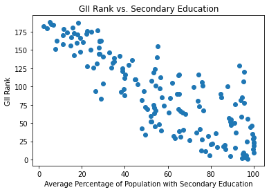

```python
main('gender_inequality.csv')
```

```python
# Be sure to select ALL THE FILES YOU NEED (including csv's)
# when you submit. As usual, you cannot edit this cell.
# Instead, run this cell to start the submission process.
from cs103 import submit

COURSE = 58946
ASSIGNMENT = 750791 # Final submission

submit(COURSE, ASSIGNMENT)

# If your submission fails, SUBMIT by downloading your files and uploading them
# to Canvas. You can learn how on the page "How to submit your Jupyter notebook"
# on our Canvas site.
```

```
Valid(value=True, description='Token')
```

```
SelectMultiple(description='Files', index=(0,), layout=Layout(height='100%', width='50%'), options=('project_m…
```

```
Button(description='submit', icon='check', style=ButtonStyle(), tooltip='submit')
```

[output not shown]